# Manuscript_figures

Anna Schedl

2026-09-20

This report allows to reproduce from the provided raw data the figures displayed in the paper. All CSV summary files represent the standardized output of the tools described in the paper and were produced with L{ae}mple.

```r
library(yaml)
library(DT)
library(jsonlite)
library(ggplot2)
library(dplyr)
library(tidyr)
library(tidyverse)
library(reshape2)
library(ggpubr)
library(ggVennDiagram)
library(lsa)
library(ggridges)
library(stringi)
library(RColorBrewer)
library(rjson)

# Read config file from params
config <- yaml::read_yaml("workflow_config_manuscript.yaml")

# color for simulation data
tool_list <- c("simulation"="#D5695DFF")

# additional labels
label.legend <- c("simulation" = "simulation",
                  "P"="Real Positive", "N"="Real Negative",
                  "PP"="Predicted Positive", "TP"="True Positive", "FP"="False Positive", "FN" = "False Negative",
                  "RMSE"="Root Mean Square Error",
                  "TPR"="True Positive Rate",
                  "FNR"="False Negative Rate", "PPV"="Positive Predictive Value", "FDR"="False Discovery Rate",
                  "jaccard_index"="Jaccard Index", "F1_score"="F1 score", "count_lineage"="Number of lineages",
                  "uniformity_wg_per"="Percent, genome min coverage",
                  "different branch" = "different branch", "parent"="parent", "child"="child",
                  "Overall" = "Overall"
                  )

for (label in config$POSTPRED$LABELS){
  label.legend[label$key] <- label$value
}
rm(label)

for (tool in config$TOOLS){
  if (tool$INCLUDE_IN_ANALYSIS){
    tool_list[tool$TOOL_NAME] <- tool$COLOUR_IN_REPORT
    label.legend[tool$TOOL_NAME] <- tool$TOOL_LABEL
  }
}
rm(tool)

# safe_labeller function, returns original value if not found in label.legends
safe_labeller <- function(x) {
  if (is.data.frame(x)) {
    out <- lapply(x, function(col) {
      mapped <- label.legend[as.character(col)]
      mapped[is.na(mapped)] <- as.character(col)[is.na(mapped)]
      mapped
    })
    return(as.data.frame(out, stringsAsFactors = FALSE))
  }

  mapped <- label.legend[as.character(x)]
  mapped[is.na(mapped)] <- as.character(x)[is.na(mapped)]
  mapped
}

#set colors
colScale <- scale_colour_manual(values = tool_list)
fillScale <- scale_fill_manual(values=tool_list)

#set up json data
# original file from "https://raw.githubusercontent.com/corneliusroemer/pango-sequences/refs/heads/main/data/pango-consensus-sequences_summary.json"
# downloaded on 21. July 2025
json.data <- jsonlite::fromJSON("pango-consensus-sequences_summary.json")

#read sample-list-all
experiment_list <- list.dirs(path=paste0("./experiments_manuscript"), full.names=FALSE, recursive=FALSE)
experiment_list <- experiment_list[grepl("Ex", experiment_list)]
experiment_list <- experiment_list[!grepl("^##", experiment_list)]

# skip Ex01_01_realdata_example for inital read-out, see Figure 6
experiment_list <- experiment_list[experiment_list != "Ex01_01_realdata_example"]
```

1. The raw results are read into data.tool.long, which contains the results from all experiments, and data.sim.long, which contains the ground-truth data as well as the corresponding sequencing quality scores.

```r
# get simulation data
for(i in 1:length(experiment_list)) {
  f = paste("./experiments_manuscript/", experiment_list[i], "/results/postPrediction/input_summary.csv", sep="")
  data.temp <- read.csv(f)
  data.temp$experiment <- experiment_list[i]
  if (i == 1) {
    data.sim <- data.temp
  } else {
    common_cols <- intersect(colnames(data.sim), colnames(data.temp))
    data.sim <- merge(x=data.sim, y=data.temp, by = common_cols, all=TRUE)
  }
}

data.sim <- data.sim %>%
  rowwise() %>%
  mutate(
    replicate = unlist(str_split(experiment, pattern = "_", n = 3, simplify = FALSE))[2],
    timecourse = unlist(str_split(experiment, pattern = "_", n = 3, simplify = FALSE))[3],
    experiment = unlist(str_split(experiment, pattern = "_", n = 3, simplify = FALSE))[1]
  )

# get all lineages that are part of simulation
sim.lineages <- colnames(data.sim %>% dplyr::select(-c("timepoint", "sample_name", "tool_name", "sample", "sample_date", "experiment", "coverage_avg", "coverage_sd", "uniformity_wg_per", "MAPQ_avg", "replicate", "timecourse")))

# create long format of simulation data
data.sim.long <- data.sim %>%
  dplyr::select(c(sim.lineages, "timepoint", "experiment", "replicate", "timecourse","coverage_avg","coverage_sd","uniformity_wg_per", "MAPQ_avg")) %>%
  gather(key="lineage", value="rel_abun", -c("timecourse", "timepoint", "experiment", "replicate", "coverage_avg", "coverage_sd", "uniformity_wg_per", "MAPQ_avg")) %>%
  filter(!is.na(rel_abun))

# fix issue if rel_abun is not in the range [0,1] but [0,100]
if(max(range(data.sim.long$rel_abun)) > 1 & max(range(data.sim.long$rel_abun)) <= 100){
  data.sim.long <- data.sim.long %>% mutate(rel_abun = rel_abun/100)
}
```

```r
# read-tool-data
data.tool <- NULL
for(i in 1:length(experiment_list)) {
  for (j in 1:length(tool_list)) {
    if(names(tool_list)[j] == "simulation") {
      next
    }  else {
      f = paste("./experiments_manuscript/", experiment_list[i], "/results/postPrediction/", names(tool_list)[j], "_summary.csv", sep="")
      data.temp <- tryCatch(read.csv(f), error=function(e) NULL)
      if (is.null(data.temp)) {
        data.temp <- data.frame(timepoint = unique(data.sim$timepoint))
      } else {
        data.temp <-  data.temp %>% dplyr::select(-c("sample_name"))
      }

      data.temp <- data.temp %>%
        mutate(experiment = experiment_list[i], tool_name = names(tool_list)[j]) %>%
        filter(!if_all(everything(), is.na))

      if (is.null(data.tool)) {
        data.tool <- data.temp
      } else {
      data.tool <- merge(x=data.tool, y=data.temp, by = intersect(colnames(data.tool), colnames(data.temp)), all=TRUE)
      }
    }
  }
}

data.tool <-  data.tool %>%
  rowwise() %>%
  mutate(
    replicate = unlist(str_split(experiment, pattern = "_", n = 3, simplify = FALSE))[2],
    timecourse = unlist(str_split(experiment, pattern = "_", n = 3, simplify = FALSE))[3],
    experiment = unlist(str_split(experiment, pattern = "_", n = 3, simplify = FALSE))[1]
  )

# add simulation data to tool data as theoretical perfect tool
data.tool <-  merge(x=data.tool, y=data.sim %>%
  dplyr::select(c(sim.lineages, "timepoint", "experiment", "replicate", "timecourse", "tool_name")),
  by = intersect(colnames(data.tool), c(sim.lineages, "timepoint", "experiment", "replicate", "timecourse", "tool_name")), all=TRUE
  )


# create long format of tools data
data.tool.long <- data.tool %>%
  gather(key="lineage", value="rel_abun", -c("timecourse", "timepoint", "experiment", "replicate", "tool_name")) %>%
  filter(!is.na(rel_abun)) %>%
  mutate(rel_abun = as.numeric(rel_abun)) %>%
  unique()

# add "uniformity_wg_per" column from simulation data
data.tool.long <- left_join(data.tool.long,
                            dplyr::select(data.sim, c("experiment", "replicate","timepoint", "uniformity_wg_per")),
                            by = c("experiment", "replicate", "timepoint"))

# fix issue if rel_abun is not in the range [0,100] but [0,1]
if(data.tool.long %>% filter(tool_name != "simulation") %>% pull(rel_abun) %>% max() <= 1 & data.tool.long %>% filter(tool_name == "simulation") %>% pull(rel_abun) %>% max() > 1){
  data.tool.long <- data.tool.long %>% mutate(rel_abun = ifelse(tool_name == "simulation", rel_abun/100, rel_abun))
}
```

2. Performance metrics are calculated by comparing the tool results in data.tool.long with the ground-truth data in data.sim.long. The resulting values are stored in data.metrics.

```r
# calculate Confusion Matrix function definition
calculateConfusionMatrix <- function(data.long, sim.data.long, grouping = TRUE) {
  data.metrics <- list()

  for (exp in unique(data.long$experiment)) {
    for (rep in unique(data.long$replicate)) {
      for (tp in unique(data.long$timepoint)) {
        for (tool in unique(data.long$tool_name)) {
          tool_df <- filter(data.long,
                            experiment == exp,
                            replicate == rep,
                            timepoint == tp,
                            tool_name == tool) %>%
            distinct(timecourse, lineage, .keep_all = TRUE)

          sim_df <- filter(sim.data.long,
                           experiment == exp,
                           replicate == rep,
                           timepoint == tp) %>%
            distinct(timecourse, lineage, .keep_all = TRUE)

          joined <- full_join(
            tool_df,
            sim_df,
            by = c("timecourse", "timepoint", "lineage", "experiment", "replicate"),
            suffix = c("", "_sim")
          )

          # now create flags
          joined <- joined %>%
            mutate(
              P  = !is.na(rel_abun_sim),
              PP = !is.na(rel_abun),
              TP = !is.na(rel_abun) & !is.na(rel_abun_sim),
              FP = !is.na(rel_abun) &  is.na(rel_abun_sim),
              FN =  is.na(rel_abun) & !is.na(rel_abun_sim),
              Error = if_else(!is.na(rel_abun_sim),
                              (coalesce(rel_abun, 0) - rel_abun_sim),
                              NA_real_)
            )

          if (grouping) {
            summary <- joined %>%
              group_by(timecourse, timepoint, experiment, replicate) %>%
              summarise(
                P  = sum(P, na.rm = TRUE),
                PP = sum(PP, na.rm = TRUE),
                TP = sum(TP, na.rm = TRUE),
                FP = sum(FP, na.rm = TRUE),
                FN = sum(FN, na.rm = TRUE),
                RMSE = sqrt(mean(Error^2, na.rm = TRUE)),
                tool_name = tool,
                .groups = "drop"
              )
            data.metrics[[length(data.metrics) + 1]] <- summary
          } else {
            # or keep joined as-is
            if(dim(joined)[1] >0){
              joined$tool_name <- tool
              data.metrics[[length(data.metrics) + 1]] <- joined
            }
          }
        }
      }
    }
  }
  return(bind_rows(data.metrics))
}

#data.metrics <- calculateConfusionMatrix(data.tool.long, data.sim.long)
## Note: above line is commented out to speed out script run time for demonstration. Pre-calculated RDS object is read instead in next code block.
```

3. The following metrics are calculated and added to data.metrics: True Positive Rate (TPR), False Negative Rate (FNR), Positive Predictive Value (PPV), False Discovery Rate (FDR), Jaccard Index, and Root Mean Square Error (RMSE), using the function described below.

```r
calculateMetrics <- function(data.metrics){
  data.metrics$TPR <- data.metrics$TP / (data.metrics$TP + data.metrics$FN)
  data.metrics$FNR <- data.metrics$FN / data.metrics$P
  data.metrics$PPV <- data.metrics$TP / data.metrics$PP #precision
  data.metrics$FDR <- data.metrics$FP / data.metrics$PP
  data.metrics$jaccard_index <- data.metrics$TP / (data.metrics$TP + data.metrics$FP + data.metrics$FN)
  data.metrics$F1_score <- (data.metrics$TP*2) / (data.metrics$TP*2 + data.metrics$FP + data.metrics$FN)
  return(data.metrics)
}

# data.metrics <- calculateMetrics(data.metrics) %>% merge(data.sim.long %>%
#              dplyr::select(timecourse, timepoint, lineage) %>%
#              unique %>% group_by(timecourse, timepoint) %>%
#              summarise(count_lineage = n(), .groups="drop"), by=c("timecourse", "timepoint")) %>%
#      merge(data.sim.long %>%
#              dplyr::select(timecourse, timepoint, experiment, replicate, uniformity_wg_per), by=c("timecourse", "timepoint", "experiment", "replicate"))

## add "uniformity_wg_per" column from simulation data

#data.metrics <- left_join(data.metrics,
#               dplyr::select(data.sim, c("experiment", "replicate","timepoint", "uniformity_wg_per")),
#               by = c("experiment", "replicate", "timepoint"))

## Note: above lines are commented out to speed out script run time for demonstration. Pre-calculated RDS object is read instead.
data.metrics <- readRDS("data.metrics.rds")
```

## Figure 1

Aggregation plot summarizing the qualitative classification performance (Jaccard Index) and the quantitative inference performance Root Mean Square Error (RMSE) for each tool using data.metrics data frame.

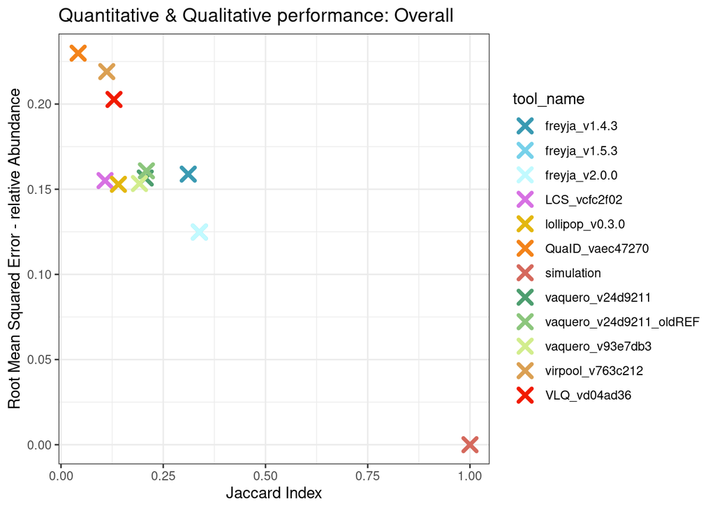

```r
tool_twoDimensionPlot <- function(data.metrics, colScale, title) {
  data.filter <- data.metrics %>%
    group_by(tool_name) %>%
    summarise(jaccard_index = mean(jaccard_index, na.rm = TRUE),
              relAb_RMSE = mean(RMSE, na.rm = TRUE), .groups="drop")

  ggplot(data.filter, aes(x=jaccard_index, y=relAb_RMSE)) +
    geom_point(aes(colour=tool_name), size = 3, shape=4, stroke=2) +
    #geom_jitter(aes(color=tool_name), size = 3, shape=4, stroke=2) +
    #facet_grid(~timecourse, labeller = safe_labeller) +
    labs(
      title=title,
      y="Root Mean Squared Error - relative Abundance",
      x="Jaccard Index") +
    colScale +
    theme_bw()
}
tool_twoDimensionPlot(data.metrics, colScale, paste("Quantitative & Qualitative performance:", "Overall"))
```

## Figure 2

This plot characterizes all detected false-positive lineages, including their phylogenetic relationships and similarity, based on shared mutations, to the closest true-positive lineage. Vertical lines indicate the mean similarity for each tool and group. The reference dataset was obtained from the curated public repository by Römer (2023) and parsed into the json.data dataframe. Phylogenetic distance was calculated as Jaccard distance and stored in the distanceMatrix dataframe. Additional data were incorporated to account for lineages missing from the reference dataset. To facilitate reproducibility, the resulting dataframes are included with the raw data files as RDS objects.

```r
getDistance <- function(var1, var2, json.data){

  var1_nuc <- c(json.data[[var1]]$nucSubstitutions, json.data[[var1]]$nucDeletions)
  var2_nuc <- c(json.data[[var2]]$nucSubstitutions, json.data[[var2]]$nucDeletions)

  if (length(var1_nuc) == 0 || length(var2_nuc) == 0){
    return(Inf)
  }

  else {

    if (var1 == "B" || var2 == "B"){
      var1_nuc <- c(var1_nuc, "SARS_COV_2")
      var2_nuc <- c(var2_nuc, "SARS_COV_2")
    }

    var1_nuc <- gsub("-", "del", var1_nuc)
    var2_nuc <- gsub("-", "del", var2_nuc)

    var1_nuc <- as.character(stri_remove_empty(var1_nuc, na_empty = FALSE))
    var2_nuc <- as.character(stri_remove_empty(var2_nuc, na_empty = FALSE))

    percent_similarityPerIndex <- length(intersect(var1_nuc, var2_nuc)) / (length(union(var1_nuc, var2_nuc)))
    return (percent_similarityPerIndex)
  }
}

getminDistance <- function(lin, tp, sim.data.long) {

  df <- sim.data.long %>%
    filter(timepoint == tp) %>% dplyr::select("lineage") %>% filter(lineage !="others") %>%
    unique() %>% rowwise() %>%
    mutate(similarity= distanceMatrix[lin, lineage])

  minDistance <- max(df$similarity)
  closestRelative <- df$lineage[df$similarity==max(df$similarity)]

  return(c(minDistance, closestRelative))
}

check_direction <- function(json.data, var1, var2, direction, n){
  # check json.data for parent or child lineage information

  # check upstream
  if (direction=="up"){
    var_parent = json.data[[var1]]$parent

    # end of search, found parent
    if (var_parent==var2){
      return = list(TRUE, n)
    }

    # end of search, not a parent
    else if(var_parent == ""){
      return = list(FALSE, 0)
    }

    else{
      n <- n +1
      check_direction(json.data, var_parent, var2, direction, n)
    }
  }

  # check downstream
  else if (direction=="down"){
    var_parent = json.data[[var2]]$parent

    # end of search, found child
    if (var_parent==var1){
      return = list(TRUE, n)
    }

    # end of search, not a child
    else if(var_parent == ""){
      return = list(FALSE, 0)
    }

    else{
      n <- n +1
      check_direction(json.data, var1, var_parent, direction, n)
    }
  }
  else {print("direction needs to be either 'up' or 'down'")}
}

check_relationship <- function(json.data, sim.data.long, var1, var2) {
  # check if variables are part of ref dataset
  #stopifnot("One or more of the variables are not part of dataset"=!is.null(json.data[[var1]]),
  #          "One or more of the variables are not part of dataset"=!is.null(json.data[[var2]]))

  if (is.null(json.data[[var1]]) | is.null(json.data[[var2]])) {
    return("not in dataset")
  }

  # check upstream
  res <- check_direction(json.data, var1, var2, "up", 1)

  if (res[[1]]){
    # found lineage is child of simulated lineage
    #print(paste("is child Number of levels:", res[[2]]))
    #print(res[[2]])
    return = "child"
  }
  else{
    #check downstream
    res <- check_direction(json.data, var1, var2, "down", 1)
    if(res[[1]]){
      # found lineage is parent of simulated lineage

      #print(paste("is parent Number of levels:", res[[2]]))
      #print(-res[[2]])
      return = "parent"
    }

    # different branch
    else{
      #print("is on different branch")
      #print(Inf)
      retun ="different branch"
    }
  }
}

CheckDistanceMatrix <- function(lineages) {
  for (i in 1:length(lineages)){
    lineage <- lineages[i]
    if(lineage != "others"){
      if (lineage %in% colnames(distanceMatrix)) {
        next
      }
      else {
        if (length(colnames(distanceMatrix)) == 0){

          colnames(distanceMatrix) <- lineage
          rownames(distanceMatrix) <- lineage
        }
        else {
          distanceData <- NULL

          for (j in 1:length(colnames(distanceMatrix))){
            distanceData <- append(distanceData, getDistance(lineage, colnames(distanceMatrix)[j], json.data))
          }

          distanceMatrix <- cbind(distanceMatrix, matrix(data=distanceData,
                                                         ncol=1, nrow=nrow(distanceMatrix),
                                                         dimnames=list(rownames(distanceData),
                                                                       lineage)
                                                         )
                                  )

          distanceMatrix <- rbind(distanceMatrix, matrix(data=NA,
                                                         ncol=ncol(distanceMatrix), nrow=1,
                                                         dimnames = list(lineage,
                                                                         colnames(distanceMatrix))
                                                         )
                                  )

        }
        index <- match(lineage, rownames(distanceMatrix))
        distanceMatrix[index, index]  <- getDistance(lineage, lineage, json.data)
        distanceMatrix <- round(distanceMatrix, 4)
      }
    }
  }
  distanceMatrix[lower.tri(distanceMatrix)] <- t(distanceMatrix)[lower.tri(distanceMatrix)]
  distanceMatrix <- as.data.frame(distanceMatrix)
  return(distanceMatrix)
}

#update = TRUE
#distanceMatrix <- CheckDistanceMatrix(unique(data.tool.long$lineage), update=update)

## manual update for missing lineages
#if (update) {
#  json.data[["B.1.1.529"]] <- "B.1.1.529"
#  json.data[["B.1.1.529"]]$children <-  c("BA.1", "BA.2", "BA.3", "BA.4", "BA.5")
#  json.data[["B.1.1.529"]]$parent <- c("B.1.1")
#  json.data[["B.1.1.529"]]$nucDeletions <- c("6513-6516", "11283-11292")
#  json.data[["B.1.1.529"]]$nucSubstitutions <- c("C241T","C3037T","T5386G","T13195C","C15240T","C25000T","A27259C","C27807T")

#  B.1.1.529_nuc <- c(json.data[["B.1.1.529"]]$nucDeletions, json.data[["B.1.1.529"]]$nucSubstitutions)

#  for (i in (1:length(colnames(distanceMatrix)))) {
#
#    var2 <- colnames(distanceMatrix)[i]
#
#    var2_nuc <- c(json.data[[var2]]$nucSubstitutions, json.data[[var2]]$nucDeletions)
#    var2_nuc <- gsub("-", "del", var2_nuc)
#
#    distance <- length(setdiff(B.1.1.529_nuc, var2_nuc)) / (length(B.1.1.529_nuc) + length(var2_nuc))
#
#    distanceMatrix["B.1.1.529",colnames(distanceMatrix)[i]] <- distance
#    distanceMatrix[colnames(distanceMatrix)[i], "B.1.1.529"] <- distance
#  }
#  distanceMatrix <- as.data.frame(distanceMatrix)
#}
## Note: above lines are commented out to speed out script run time for demonstration. Pre-calculated RDS object is read instead.

## Pre-calculated RDS object
distanceMatrix <- readRDS("distanceMatrix.rds")
```

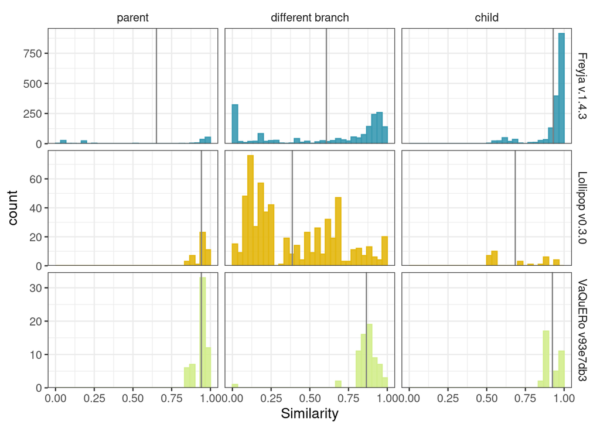

```r
#fp_distance <- calculateConfusionMatrix(data.tool.long, data.sim.long, grouping = FALSE) %>%
#      filter(FP == 1, lineage != "others") %>%
#      group_by(tool_name, lineage, timepoint) %>%
#      dplyr::select(c("tool_name", "lineage", "timepoint")) %>%
#      unique() %>% arrange(tool_name) %>% ungroup() %>%
#      rowwise() %>% mutate(min_distance = as.numeric(getminDistance(lineage, timepoint, data.sim.long)[1]),
#                       closest_relative = getminDistance(lineage, timepoint, data.sim.long)[2],
#                       relationship = check_relationship(json.data, data.sim.long, lineage, closest_relative)
#                       ) %>%
#      filter(!is.infinite(min_distance))

## Note: above lines are commented out to speed out script run time for demonstration. Pre-calculated RDS object is read instead.
fp_distance <- readRDS("FP_distances.rds")

fp_distance_toi <- fp_distance %>% filter(tool_name %in% c("freyja_v1.4.3", "lollipop_v0.3.0", "vaquero_v93e7db3"))

fp_distance_toi$relationship <- factor(
  fp_distance_toi$relationship,
  levels = c("parent", "different branch", "child")
)

ggplot(filter(fp_distance_toi, relationship != "not in dataset"), aes(x=min_distance, color=tool_name, fill=tool_name)) +
    geom_histogram(position = 'identity', alpha=0.9, boundary=0) +
    geom_vline(data=. %>% group_by(relationship, tool_name) %>% summarize(x=mean(min_distance)), aes(xintercept=x), color="grey50") +
    facet_grid(tool_name~relationship, scales = "free_y", labeller = safe_labeller) +
    colScale +
    fillScale +
    scale_y_continuous(expand=expansion(mult = c(0,0.05))) +
    theme_bw() +
    theme(
     legend.position = "none",
     text = element_text(size=12),
     strip.background = element_blank()
    ) +
    labs(x = "Similarity") +
    NULL
```

## Figure 3

Figure 3 uses the data.metrics dataset to compare SARS-CoV-2 lineage deconvolution performance between Freyja (v1.4.3) and VaQuERo (v93e7db3) across three simulated datasets (Omicron time-course, VOC time-course, and Vienna time-course), as well as an overall aggregated analysis. For each tool and dataset, two performance metrics are shown: positive predictive value (PPV; circles) and true positive rate (TPR; triangles).

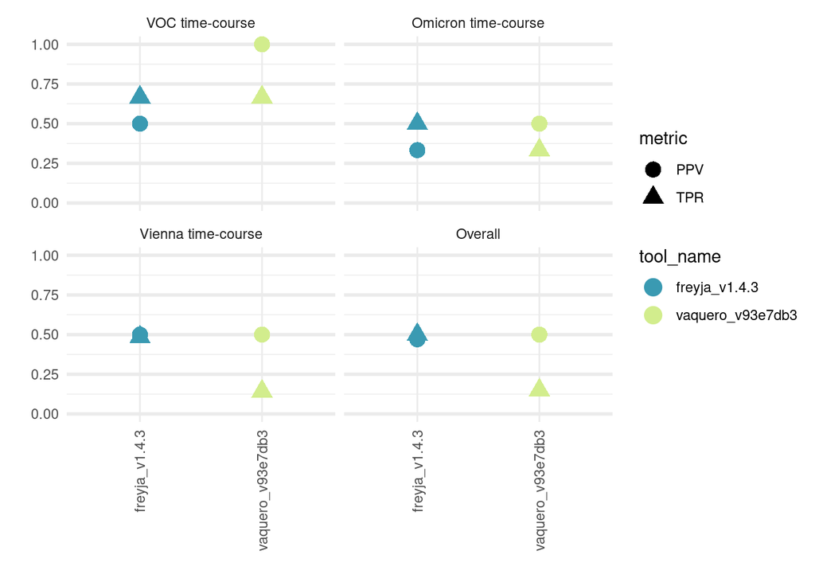

```r
t <- bind_rows(
    data.metrics %>% filter(tool_name %in% c("freyja_v1.4.3", "vaquero_v93e7db3")) %>%
  select(tool_name, timecourse, PPV, TPR) %>%
  group_by(tool_name, timecourse) %>%
  summarise(PPV = median(PPV, na.rm = TRUE),
            TPR = median(TPR, na.rm = TRUE),
            .groups = "drop") %>%
    gather(key="metric", value="value", -c("tool_name", "timecourse")),

  data.metrics %>% filter(timecourse!="realdata_example") %>% filter(tool_name %in% c("freyja_v1.4.3", "vaquero_v93e7db3")) %>%
  select(tool_name, PPV, TPR) %>%
  group_by(tool_name) %>%
  summarise(PPV = median(PPV, na.rm = TRUE),
            TPR = median(TPR, na.rm = TRUE)) %>%
    gather(key="metric", value="value", -c("tool_name")) %>%
  mutate(timecourse="Overall")
  ) %>%
  mutate(
    timecourse = factor(
      timecourse,
      levels = c("WideQual", "nearQual", "realTimecourse", "Overall")
    ))

ggplot(t, aes(x=tool_name, y=value, color=tool_name)) +
  geom_point(aes(shape=metric, color=tool_name), size=4, stroke=1) +
  theme_minimal() + ylab("") +
  theme(axis.text.x = element_text(angle = 90, vjust = 0.5, hjust=1)) +
  coord_cartesian(ylim = c(0, 1)) +
  facet_wrap(~timecourse, labeller = safe_labeller) +
  theme(
        panel.grid.major.y = element_line(linewidth = 1),
        ) +
      labs(x = "") +
      colScale
```

## Figure 4

Figure 4 uses the data.metrics dataset to compare lineage identification performance of the SARS-CoV-2 lineage deconvolution tool VaQuERo (v24d921) using either the default or an older reference dataset (oldREF). Positive predictive value (PPV) and true positive rate (TPR) are shown as individual data points for each reference configuration, representing the median values for simulated dataset.

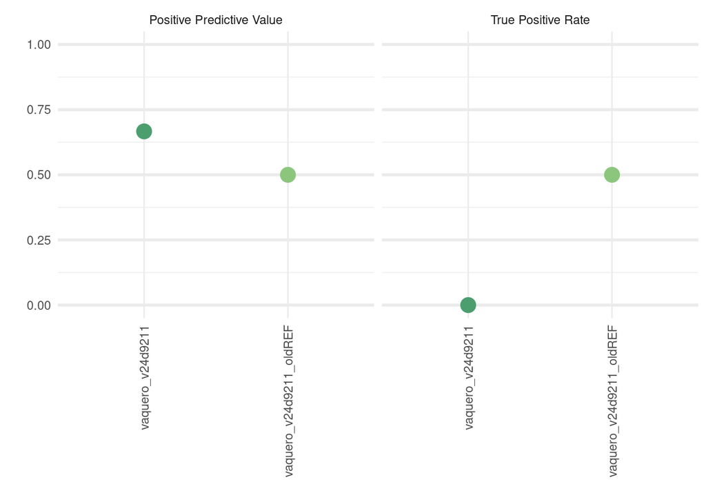

```r
t <- data.metrics %>% filter(timecourse=="nearQual") %>%
  filter(tool_name %in% c("vaquero_v24d9211", "vaquero_v24d9211_oldREF")) %>%
    select(tool_name, PPV, TPR) %>%
    group_by(tool_name) %>%
    summarise(PPV = median(PPV, na.rm = TRUE),
              TPR = median(TPR, na.rm = TRUE)) %>%
      gather(key="metric", value="value", -c("tool_name"))

ggplot(t, aes(x=tool_name, y=value, color=tool_name)) +
  geom_point(aes(color=tool_name), size=4, stroke=1) +
  theme_minimal() + ylab("") +
  theme(axis.text.x = element_text(angle = 90, vjust = 0.5, hjust=1)) +
  coord_cartesian(ylim = c(0, 1)) +
  facet_wrap(~metric, labeller = safe_labeller) +
  theme(
        panel.grid.major.y = element_line(linewidth = 1),
        legend.position="none"
        ) +
      labs(x = "") +
      colScale
```

## Figure 5

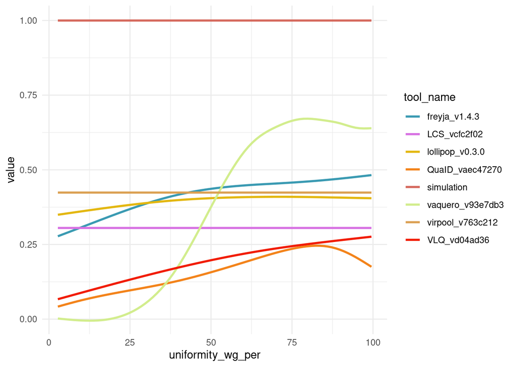

```r
tools_to_use <- c("freyja_v1.4.3", "LCS_vcfc2f02", "lollipop_v0.3.0", "QuaID_vaec47270", "simulation", "vaquero_v93e7db3", "virpool_v763c212", "VLQ_vd04ad36")

t <- data.metrics %>%
  filter(tool_name %in% tools_to_use) %>%
  group_by(tool_name, uniformity_wg_per) %>%
      summarise("P" = sum(P,  na.rm = TRUE),
                "PP" = sum(PP,  na.rm = TRUE),
                "TP" = sum(TP,  na.rm = TRUE),
                "FP" = sum(FP,  na.rm = TRUE),
                "FN" = sum(FN,  na.rm = TRUE),
                "RMSE" = mean(RMSE,  na.rm = TRUE), .groups = "drop")

t <- calculateMetrics(t)
t$PPV[is.nan(t$PPV)]<-0
t <- t %>% select(tool_name, uniformity_wg_per, PPV) %>% gather(key = "metric", value = "value", -tool_name, -!!sym("uniformity_wg_per"))

# Detect constant-value tool groups (y is identical)
const_groups <- t %>%
  group_by(tool_name, metric) %>%
  summarise(is_const = n_distinct(value) == 1, .groups = "drop")

constant_df <- semi_join(t, const_groups %>% filter(is_const),
                                  by = c("tool_name", "metric"))
variable_df <- anti_join(t, const_groups %>% filter(is_const),
                                  by = c("tool_name", "metric"))

# create plot
ggplot() +
    geom_line(
      data = constant_df,
      aes(x = !!sym("uniformity_wg_per"), y = value, color = tool_name),
      size = 1
    ) +
    geom_smooth(
      data = variable_df,
      aes(x = !!sym("uniformity_wg_per"), y = value, color = tool_name),
      se = FALSE
    ) + colScale +
    coord_cartesian(ylim = c(0, 1)) +
    theme_minimal()
```

## Figure 6

Figure 6A uses a subset of the simulated Vienna timecourse dataset to compare whole-genome coverage (uniformity_wg_per, in %) with newly importet sequencing data. The “Real” category represents data obtained from real sequencing data (realData_example), whereas all other experiments represent simulated datasets. SWAMPy quality parameters were extracted from the log files of each experiment using the parameter “Amplicon Pseudocount,” which documents the parameter settings for each experimental run.

Figure 6A therefore compares whole-genome coverage as a proxy for sequencing quality between simulated and real-world datasets. Figure 6B compares qualitative and quantitative lineage deconvolution performance between real-world samples and simulated samples with comparable sequencing quality, demonstrating that performance trends observed in the simulated data closely resemble those observed in real-world wastewater samples.

```r
## get real sequencing data
data.seq <- read.csv("./experiments_manuscript/Ex01_01_realdata_example/results/postPrediction/input_summary.csv")
data.seq$experiment <- "Ex01_01_realdata_example"

data.seq <- data.seq %>%
  rowwise() %>%
  mutate(
    replicate = unlist(str_split(experiment, pattern = "_", n = 3, simplify = FALSE))[2],
    timecourse = unlist(str_split(experiment, pattern = "_", n = 3, simplify = FALSE))[3],
    experiment = unlist(str_split(experiment, pattern = "_", n = 3, simplify = FALSE))[1]
  )

# get all lineages that are part of simulation
seq.lineages <- colnames(data.seq %>% dplyr::select(-c("timepoint", "sample_name", "tool_name", "sample", "sample_date", "experiment", "coverage_avg", "coverage_sd", "uniformity_wg_per", "MAPQ_avg", "replicate", "timecourse")))

## create long format of simulation data
data.seq.long <- data.seq %>%
  dplyr::select(c(seq.lineages, "timepoint", "experiment", "replicate", "timecourse","coverage_avg","coverage_sd","uniformity_wg_per", "MAPQ_avg")) %>%
  gather(key="lineage", value="rel_abun", -c("timecourse", "timepoint", "experiment", "replicate", "coverage_avg", "coverage_sd", "uniformity_wg_per", "MAPQ_avg")) %>%
  filter(!is.na(rel_abun))

# fix issue if rel_abun is not in the range [0,1] but [0,100]
if(max(range(data.seq.long$rel_abun)) > 1 & max(range(data.seq.long$rel_abun)) <= 100){
  data.seq.long <- data.seq.long %>% mutate(rel_abun = rel_abun/100)
}

# experiment "realdata" using real sequencing data was not run with complete tool list, therefore some input files do not exist.
tools_to_use <- c("freyja_v2.0.0", "lollipop_v0.3.0", "vaquero_v24d9211", "virpool_v763c212", "VLQ_vd04ad36")
data.seq.tool <- NULL

for (j in 1:length(tools_to_use)) {
  data.temp <- read.csv(paste("./experiments_manuscript/Ex01_01_realdata_example/results/postPrediction/", tools_to_use[j], "_summary.csv", sep=""))
  if (is.null(data.temp)) {
    data.temp <- data.frame(timepoint = unique(data.seq$timepoint))
    } else {
        data.temp <-  data.temp %>% dplyr::select(-c("sample_name"))
    }
    data.temp <- data.temp %>%
      mutate(experiment = "Ex01_01_realdata_example", tool_name = tools_to_use[j]) %>%
      filter(!if_all(everything(), is.na))
    if (is.null(data.seq.tool)) {
      data.seq.tool <- data.temp
      } else {
        data.seq.tool <- merge(x=data.seq.tool, y=data.temp, by = intersect(colnames(data.seq.tool), colnames(data.temp)), all=TRUE)
      }
  }

data.seq.tool <-  data.seq.tool %>%
  rowwise() %>%
  mutate(
    replicate = unlist(str_split(experiment, pattern = "_", n = 3, simplify = FALSE))[2],
    timecourse = unlist(str_split(experiment, pattern = "_", n = 3, simplify = FALSE))[3],
    experiment = unlist(str_split(experiment, pattern = "_", n = 3, simplify = FALSE))[1]
  )

# create long format of tools data
data.seq.tool.long <- data.seq.tool %>%
  gather(key="lineage", value="rel_abun", -c("timecourse", "timepoint", "experiment", "replicate", "tool_name")) %>%
  filter(!is.na(rel_abun)) %>%
  mutate(rel_abun = as.numeric(rel_abun)) %>%
  unique()

# add "uniformity_wg_per" column from sequencing data
data.seq.tool.long <- left_join(data.seq.tool.long,
                            select(data.seq, c("experiment", "replicate","timepoint", "uniformity_wg_per")),
                            by = c("experiment", "replicate", "timepoint"))

# fix issue if rel_abun is not in the range [0,100] but [0,1]
# data.tool.long %>% group_by(tool_name) %>% summarize(max = max(rel_abun))
if(data.seq.tool.long %>% filter(tool_name != "simulation") %>% pull(rel_abun) %>% max() <= 1 & data.tool.long %>% filter(tool_name == "simulation") %>% pull(rel_abun) %>% max() > 1){
  data.seq.tool.long <- data.seq.tool.long %>% mutate(rel_abun = ifelse(tool_name == "simulation", rel_abun/100, rel_abun))
}

#data.seq.metrics <- calculateConfusionMatrix(data.seq.tool.long, data.seq.long)

#data.seq.metrics <- calculateMetrics(data.seq.metrics) %>% merge(data.seq.long %>%
#              select(timecourse, timepoint, lineage) %>%
#              unique %>% group_by(timecourse, timepoint) %>%
#              summarise(count_lineage = n(), .groups="drop"), by=c("timecourse", "timepoint")) %>%
#              merge(data.seq.long %>%
#              select(timecourse, timepoint, experiment, replicate, uniformity_wg_per), by=c("timecourse", "timepoint", "experiment", "replicate"))

## Note: above lines are commented out to speed out script run time for demonstration. Pre-calculated RDS object is read instead.
data.seq.metrics <- readRDS("data.seq.metrics.rds")
```

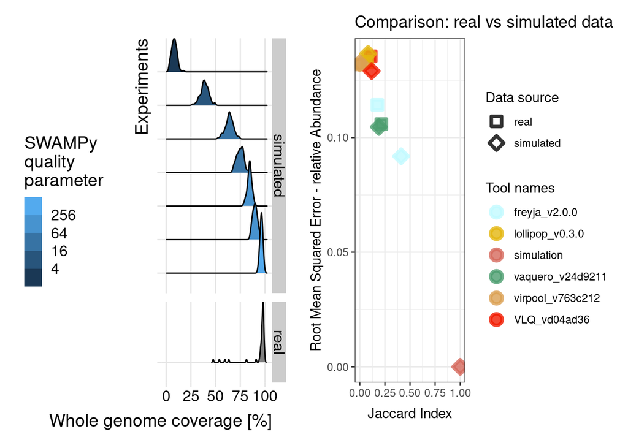

```r
title = "Figure 6"
tools_to_use <- c("freyja_v2.0.0", "lollipop_v0.3.0", "simulation", "vaquero_v24d9211", "virpool_v763c212", "VLQ_vd04ad36")

sim_dm.dt <- data.metrics %>% filter(timecourse == "realTimecourse") %>% filter(grepl("Ex", experiment)) ##checked
real_dm.dt <- data.seq.metrics
real_dm.dt <- real_dm.dt %>% distinct()
sim_dm.dt  <- sim_dm.dt %>% distinct()
dm.dt <- rbind(real_dm.dt, sim_dm.dt)


# plot uniformity_wg_per distribution
library(data.table)
qc.dt <- dm.dt %>% select(timecourse, timepoint, experiment, replicate, uniformity_wg_per) %>% distinct()
ex2qc.dt <- data.table(experiment = paste0("Ex", 16:22), qscore = config$SIMULATION$QUALITY_SCORES)
qc.dt <- left_join(x = qc.dt, y = ex2qc.dt, by = "experiment")
qc.dt <- qc.dt %>% mutate(timecourse = ifelse(timecourse == "realTimecourse", "simulated", "real"))
qc.dt$timecourse <- factor(qc.dt$timecourse, levels = c("simulated", "real"))
pqc <-  ggplot(qc.dt, aes(x = uniformity_wg_per, y = paste(timecourse, experiment))) + ggridges::geom_density_ridges(aes(fill = qscore)) + ggridges::theme_ridges() + facet_grid(timecourse~., scale = "free_y", space = "free") + xlab("Whole genome coverage [%]") + ylab("Experiments") + theme(axis.text.y = element_blank()) + scale_fill_binned(name="SWAMPy\nquality\nparameter", trans = "log2") + theme(legend.position = "left")

# make qualitative vs quantitative results plot for sim (Ex16, since the most similar w.r.t genome coverage) vs real(Ex01)
tool_list <- tool_list[names(tool_list) %in% tools_to_use]
dm.dt <- dm.dt %>% filter(tool_name %in% names(tool_list))

recall.dt <- dm.dt %>% mutate(timecourse = ifelse(timecourse == "realTimecourse", "simulated", "real")) %>% filter(experiment %in% c("Ex16", "Ex01")) %>% group_by(timecourse, tool_name) %>%
  summarise(jaccard_index = mean(jaccard_index, na.rm = TRUE),
            relAb_RMSE = mean(RMSE, na.rm = TRUE), .groups="drop") # %>% filter(tool_name != "simulation")

pdm <- ggplot(recall.dt, aes(x=jaccard_index, y=relAb_RMSE, color = tool_name, fill = tool_name)) +
  geom_point(aes(shape = timecourse), size = 3, stroke=2, alpha = .80) +
  labs(
    title="Comparison: real vs simulated data",
    y="Root Mean Squared Error - relative Abundance",
    x="Jaccard Index") +
  scale_colour_manual(values = tool_list, name = "Tool names") +
  scale_fill_manual(values = tool_list, name = "Tool names") +
  scale_shape_manual(name = "Data source", values = c(22,23)) +
  theme_bw() +
  NULL

library(patchwork)
pqc + pdm
```